# Задание 1

Романчук Олег Арсентьевич

Assigned: October 7, 2019

#ilya.tetin@susu.ru Тетин Илья Алексеевич ##### Для выполнения задания следуйте следующему:

1. Замените “Введите имя” в поле `author:` на свое ФИО.
2. Выполняйте задание путем редактирования файла `homework1.Rmd`.
3. После выполнения работы, убедитесь, что ваш код выполняется как в консоле, так и путем запуска knit HTML, поменяйте название сохраненного файла на `homework1_Вашеимя.Rmd` (Вашеимя поменяйте на ФИО) и отправьте на почту “itetin.emms@yandex.ru”

##### Homework tips:

1. Вместо построчного запуска путем нажатия `<ctrl-enter>` можно запускать целые блоки кода. Посмотрите опции в меню
2. Проверяйте код в консоле, запускайте Knit HTML по мере выполнения для проверки на ошибки.

### Задание 1: Простые Булевы операции

> Tip: Обратите внимание, что в каждом блоке кода стоит опция `eval = FALSE`. Это говорит R Markdown отображать код внутри блока, но не запускать его. Для проверки ответа, убедитесь, что код работает в консоли для различных значений переменной `x`

##### (a) Проверка равенства.

Дана переменная `x`, запишите Булево выражение, которое возвращает `TRUE` если переменная `x` равна `94842` (numeric).

```r
x = 94842
x == 94842

#x <- c(94841,94842,94843); names(x)<- as.character(x)
#x <- (x == 94842)
#x
```

##### (b) Проверка неравенства.

Дана переменная `x`, запишите Булево выражение, которое возвращает `TRUE` если переменная `x` *не* `NA` (т.е., не пропущена).

```r
x = 5
x | NA
length(x) != 0
```

##### (c) Проверка, что число находится в заданном диапазоне.

Пусть дано (можно отрицательное) число `x`, запишите Булево выражение, которое возвращает `TRUE` только в том случае, если `x` меньше `-12` или больше, чем `29`.

```r
x = -13
x < -12 | x > 29
```

```
## [1] TRUE
```

```r
#x <- c(-13,0,30); names(x)<- as.character(x)
#x <- (x < -12 | x > 29)
#x
```

##### (d) Более сложное задание.

Задано целове число `x`, запишите Булево выражение, которое возвращает `TRUE` только в том случае, если `x` является **нечетным** числом между -8 и 12 или 100 и 150.

```r
x = 1
((x > -8 & x < 12) | (x > 100 & x < 150 )) & ((x %% 2) != 0)

#x <- c(-10,-9,0,1,13,14,101,102,151,151); names(x)<- as.character(x)
#x <- (((x > -8 & x < 12) | (x > 100 & x < 150 )) & ((x %% 2) != 0))
#x
```

**Tip**: Остаток от деления: `%%`. Для целых `x` и `y`, `x %% y` является остатком от `x` разделенного на `y`.

### Задание 2: Векторные Булевы операции

##### (a) R имеет два типа Булевых операторов, одинарный (`&`, `|`) и двойной (`&&`, `||`).

Один из этих операторов имеет свойство, называемое *lazy evaluation*, другой - не имеет. Они ведут себя по-разному, когда применяются к *vectors*.

Прочитайте (`help("||")`) и постройте несколько примеров, чтобы помочь разобраться, как эти операторы себя ведут

В качестве отправной точки, попробуйте следующие примеры в консоле:

```r
# Example:  Переменная y.prob2a не задана.
# (Не задавайте ее!)
# Что произойдет при запуске кода?
x.prob2a <- 5
(x.prob2a < 10) | (y.prob2a > 2)
(x.prob2a < 10) || (y.prob2a > 2)

(x.prob2a < 10) & (y.prob2a > 2)
(x.prob2a < 10) && (y.prob2a > 2)

x.prob2a <- 11
(x.prob2a < 10) || (y.prob2a > 2)
```

```r
# Задайте векторы
# Пример 1
x.prob2a.vec <- c(TRUE, FALSE, FALSE)
y.prob2a.vec <- c(TRUE, TRUE, FALSE)

# Примените различные Булевы операции и посмотрите на результат
x.prob2a.vec & y.prob2a.vec
x.prob2a.vec && y.prob2a.vec
x.prob2a.vec | y.prob2a.vec
x.prob2a.vec || y.prob2a.vec

# Пример 2
x.prob2a.vec <- c(TRUE, TRUE, FALSE)
y.prob2a.vec <- c(FALSE, TRUE, FALSE)

x.prob2a.vec && y.prob2a.vec

# Пример 3
x.prob2a.vec <- c(FALSE, TRUE, FALSE)
y.prob2a.vec <- c(TRUE, TRUE, FALSE)

x.prob2a.vec || y.prob2a.vec
```

Вы можете объяснить, что происходит? Ниже кратко поясните.

Применительно к векторам, короткие формы AND и OR производят поэлементное сравнение векторов. Длинные формы AND и OR производят сравнение только первых элементов веторов. Это показывает пример 2 (строка 122). Причем сравнение выполняется до тех пор, пока результат не будет определен. Это поведение можно изучить на следующих примерах: - строка 97 (при x.prob2a = 5) – при получении значения операции x.prob2a < 10 (TRUE), операция сравнения y.prob2a > 2 не выполняется - строка 103 (она идентична строке 97, но x.prob2a присвоено значение 11) – при получении значения операции x.prob2a < 10 (FALSE), производится выполнение операции y.prob2a > 2, для вычисления второго значения операции сравнения, в результате чего, скрипт завершается с ошибкой - пример 3 (строка 129).

##### (b) Применение `all()`

Опросили двух человек, которые выбирали из двух вариантов ответов: [Facebook, Twitter], [Firefox, Chrome], [Mac, PC], [Summer, Winter]. Результаты приведены ниже

```r
alice.prefs <- c("Twitter", "Chrome", "Mac", "Summer")
bob.prefs <- c("Facebook", "Chrome", "PC", "Summer")
```

Примените функцию `all()` для определения, одинаковы ли предпочтения людей. (Ваш код должен выводить одиночную Булеву переменную `TRUE` или `FALSE`)

```r
all(alice.prefs == bob.prefs)
```

```
## [1] FALSE
```

```r
#alice.prefs <- bob.prefs
#all(alice.prefs == bob.prefs)
```

##### (c) Применение `any()`

Используйте функцию `any()` для определения, имеют ли два человека какие-либо общие предпочтения. function to determine if the two people have any preferences in common. (Ваш код должен выводить одиночную Булеву переменную `TRUE` или `FALSE`)

```r
any(alice.prefs == bob.prefs)
```

```
## [1] TRUE
```

##### (d) Пропущенные значения.

Пусть `age` будет вектором. Он определен ниже

```r
age <- c(18, NA, 25, 71, NA, 45, NA, NA, 18)
```

Напишите Булево выражение, которое проверяет каждое значение на пропущенное (`NA`). Ваше выражение должно возвращать Булевый вектор, имеющий длину как у `age`.

```r
age | NA
```

```
## [1] TRUE   NA TRUE TRUE   NA TRUE   NA   NA TRUE
```

```r
length(age | NA) == length(age)
```

```
## [1] TRUE
```

### Задание 3: Обращение к элементам вектора

##### (a) Задание по `which()`

Напишите код, который возвращает пропущенные индексы `age`

```r
which(age[!age] | NA)
```

```
## integer(0)
```

```r
which(age | NA)
```

```
## [1] 1 3 4 6 9
```

```r
# не могу выполнить задание без is.na. which пропускает логическую константу NA -- получаю вектор нулевой длины integer(0)
```

##### (b) Получение присутствующих значений

Напишите код, который использует негативные индексы и ваше решение из части (а), чтобы вернуть только те значения `age`, которые присутствуют (ваш код должен возвращать вектор с элементами: 18, 25, 71, 45, 18)

```r
age[which(age | NA)]
```

```
## [1] 18 25 71 45 18
```

##### (c) Более прямой путь получения присутствующих значений

Используя оператор `!` и функцию `is.na()` напишите выражение, которое возвращает присутсвующие значения переменной `age`

```r
age[which(!is.na(age))]
```

```
## [1] 18 25 71 45 18
```

##### (d) Больше практики по `which()`

Для следующей задачи вернемся к набору данных `cars`

```r
speed <- cars$speed
dist <- cars$dist
```

Напишите код, чтобы определить какие машины останавливаются за 15 футов или за большее расстояние.

```r
which(dist >= 15)
```

```
##  [1]  4  5  7  8  9 10 11 13 14 15 16 17 18 19 20 21 22 23 24 25 26 27 28
## [24] 29 30 31 32 33 34 35 36 37 38 39 40 41 42 43 44 45 46 47 48 49 50
```

##### (e) Задание `which.min`, `which.max`

Используйте функцию `which.min()` для определения *кратчайшей* дистанции остановики. (Код должен возвращать индекс автомобиля)

```r
which.min(dist)
```

```
## [1] 1
```

##### (f) Еще практика

Используйте функцию `which.max()`для определения *скорости* машины с *длиннейшей* дистанцией остановки. (Код должен возвращать скорость автомобиля)

```r
speed[which.max(dist)]
```

```
## [1] 24
```

### Задание 4: Основы работы с data.frame

##### (a) Импорт данных

Необходимо загрузить файл по ссылке https://cloud.mail.ru/public/4wCu/2s76mCEB7 В файле survey_data.csv содержатся данные опроса. Поместите файл в рабочий каталог, затем импортируйте данные функцией `read.csv()`в переменную `survey`

```r
survey <- read.csv('survey_data.csv')
```

**Tip**: Не используйте прямое скачивание файла из облака.

##### (b) `$` нотация

Воспользуйтесь оператором `$` для выбора колонки TVhours из `survey`

```r
survey$TVhours
```

```
##  [1]  2 15 16  0  2  5  0  4  0  0 14  6 10 15  4  4 10  7 33  8  8  3  0
## [24]  0  0  0  6  1  0  0  4
```

##### (c) [,] нотация

Повторите часть (b), используя `[,]` нотацию, т.е., используйте `[,]` для выбора столбца TVhours из `survey` по имени (воспользуйтесь именем “TVhours” вместо указания на номер столбца)

```r
survey[,'TVhours']
```

```
##  [1]  2 15 16  0  2  5  0  4  0  0 14  6 10 15  4  4 10  7 33  8  8  3  0
## [24]  0  0  0  6  1  0  0  4
```

##### (d) [[]] нотация

Повторите часть (c) с использованием [[]] нотации

```r
survey[["TVhours"]]
```

```
##  [1]  2 15 16  0  2  5  0  4  0  0 14  6 10 15  4  4 10  7 33  8  8  3  0
## [24]  0  0  0  6  1  0  0  4
```

##### (e) [] нотация

Повторите часть (d) используя одиночные скобки (`[ ]`) (В этот раз возвращается *data frame*, а не вектор.)

```r
survey["TVhours"]
```

```
##    TVhours
## 1        2
## 2       15
## 3       16
## 4        0
## 5        2
## 6        5
## 7        0
## 8        4
## 9        0
## 10       0
## 11      14
## 12       6
## 13      10
## 14      15
```

[output cut: 17 more lines]

##### (f) `subset()`

```r
subset(survey, (survey$Rexperience == "Never used") & (survey$TVhours >= 5), select = c(Program, OperatingSystem))
```

```
##    Program OperatingSystem
## 2      PPM         Windows
## 6      PPM         Windows
## 14   Other         Windows
## 20   Other         Windows
```

### Задача 5: практика программирования

##### (a) Bar graph

Создайте столбчатую диаграмму ответов респондентов по Rexperience

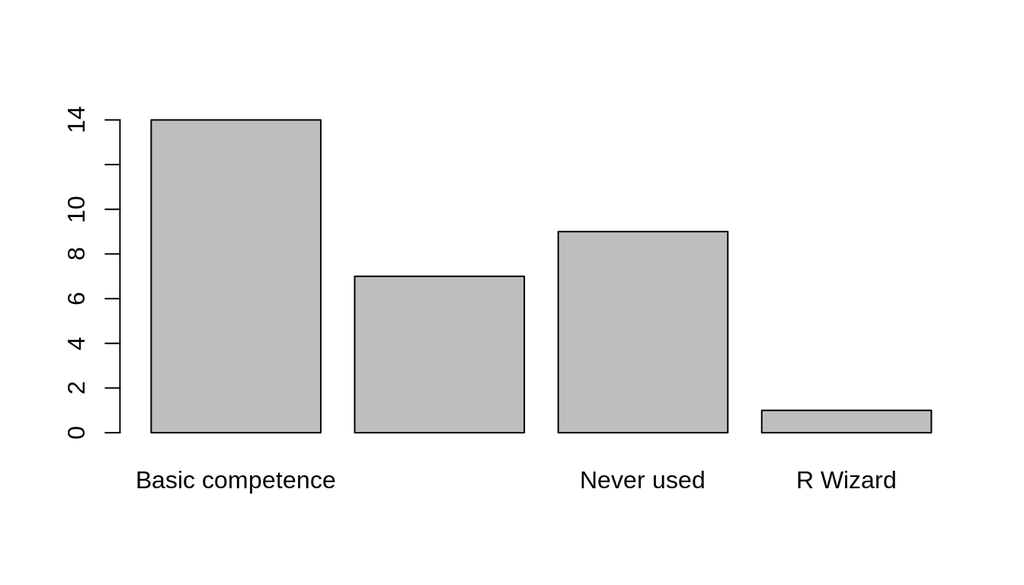

```r
plot(survey$Rexperience)
```

##### (b) Inline code

Замените все знаки вопроса в следующем параграфе inline кодом, дополняющим подходящую информацию Replace all occurrences of ???? in the paragraph below with an inline code chunk supplying the appropriate information.

> Из 31 респондентов опроса, 27 НЕ были в программе MISM. Мы обнаружили, что 35.48% от числа студентов в классе используют Mac OS X. 50% от MISM студентов имеют базовые компетенции в R.

### Задача с пятницы 11.10.2019.

Повернуть матрицу на 90 градусов

```r
rotate <- function(m){
  a <- unlist(attributes(m), use.names = F)
  m <- t(m)
  for(i in 0:a[2]){
    m[i,]=rev(m[i,])
  }
  return (m)
}
mx <- matrix(1:6,nrow = 2, ncol = 3)
mx
```

```
##      [,1] [,2] [,3]
## [1,]    1    3    5
## [2,]    2    4    6
```

```r
rotate(mx)
```

```
##      [,1] [,2]
## [1,]    2    1
## [2,]    4    3
## [3,]    6    5
```

```r
# В R нашелся синтаксический сахар.
rotate <- function(m){
  t(apply(m, 2, rev))
}

mx <- matrix(1:6,nrow = 2, ncol = 3)
mx
```

```
##      [,1] [,2] [,3]
## [1,]    1    3    5
## [2,]    2    4    6
```

```r
rotate(mx)
```

```
##      [,1] [,2]
## [1,]    2    1
## [2,]    4    3
## [3,]    6    5
```